# Bicyles Data

Dear Client,

Thank you for providing us with the three datasets from Sprocket Central Pty Ltd. We highlighted the data quality issues below as well as the profits made from each brand based on the customer demographics and the transaction history. Please let us know if the figures are not aligned with your understanding.

*In the transactions part:*

- Product first sold date is not accurate, it is not shown as a date.
- There are duplicates in customer ids

*In Customer Demographics, the data is not tidy as well.*

```python
import pandas as pd
```

```python
df= pd.read_excel("/Users/Kantemirovs/Desktop/customer_demographic.xlsx")
```

We eliminated the default column since the data in the column was not clear we did not want it to interfere with the analysis

```python
df=df.drop('default',axis=1)
```

```python
df
```

|  | customer_id | first_name | last_name | gender | past_3_years_bike_related_purchases | DOB | job_title | job_industry_category | wealth_segment | deceased_indicator | owns_car | tenure |
| --- | --- | --- | --- | --- | --- | --- | --- | --- | --- | --- | --- | --- |
| 0 | 720 | Darrel | Canet | Male | 67 | 1931-10-23 | Recruiting Manager | Retail | Affluent Customer | N | No | 6.0 |
| 1 | 1092 | Katlin | Creddon | Female | 56 | 1935-08-22 | VP Quality Control | Retail | Mass Customer | N | No | 5.0 |
| 2 | 3410 | Merrili | Brittin | Female | 93 | 1940-09-22 | NaN | Property | Mass Customer | N | No | 16.0 |
| 3 | 2413 | Abbey | Murrow | Male | 27 | 1943-08-11 | Environmental Specialist | Manufacturing | High Net Worth | N | Yes | 17.0 |
| 4 | 658 | Donn | Bonnell | Male | 38 | 1944-01-24 | Tax Accountant | Manufacturing | Affluent Customer | N | Yes | 8.0 |
| ... | ... | ... | ... | ... | ... | ... | ... | ... | ... | ... | ... | ... |
| 3995 | 3779 | Ulick | Daspar | U | 68 | NaT | NaN | IT | Affluent Customer | N | No | NaN |
| 3996 | 3883 | Nissa | Conrad | U | 35 | NaT | Legal Assistant | IT | Mass Customer | N | No | NaN |
| 3997 | 3931 | Kylie | Epine | U | 19 | NaT | NaN | IT | High Net Worth | N | Yes | NaN |
| 3998 | 3935 | Teodor | Alfonsini | U | 72 | NaT | NaN | IT | High Net Worth | N | Yes | NaN |
| 3999 | 3998 | Sarene | Woolley | U | 60 | NaT | Assistant Manager | IT | High Net Worth | N | No | NaN |

4000 rows × 12 columns

Transaction sheet provides data about the customers that actually executed orders. Thus, I wanted to merge both customer demographics dataframe and transactions dataframe as well as Customer Address dataframe on Customer ID to include the customers that ordered bikes, and filter out those who did not.

```python
transactions=pd.read_excel("/Users/Kantemirovs/Desktop/Transactions.xlsx")
address=pd.read_excel("/Users/Kantemirovs/Desktop/CustomerAddress.xlsx")
```

```python
df_merged=pd.merge(df, transactions, left_on=['customer_id'],
              right_on=['customer_id'],
              how='inner')
df_merged=pd.merge(df_merged,address,left_on=['customer_id'],
              right_on=['customer_id'],
              how='inner')
```

There were duplicates for the customer_id column. Thus we eliminated them by dropping the rows that has the same client first and last name

```python
df_merged.drop_duplicates(subset =["first_name","last_name","DOB"],
                     keep = False, inplace = True)
```

```python
df_merged
```

|  | customer_id | first_name | last_name | gender | past_3_years_bike_related_purchases | DOB | job_title | job_industry_category | wealth_segment | deceased_indicator | ... | product_class | product_size | list_price | standard_cost | product_first_sold_date | address | postcode | state | country | property_valuation |
| --- | --- | --- | --- | --- | --- | --- | --- | --- | --- | --- | --- | --- | --- | --- | --- | --- | --- | --- | --- | --- | --- |
| 1143 | 2807 | Lynna | Revens | Female | 9 | 1957-06-18 | Senior Editor | Manufacturing | Mass Customer | N | ... | medium | small | 1216.14 | 1082.36 | 34527.0 | 441 Superior Junction | 2320 | NSW | Australia | 6 |
| 1685 | 3279 | Morgun | Razoux | Male | 55 | 1959-02-18 | Staff Scientist | Financial Services | Mass Customer | N | ... | medium | large | 1071.23 | 380.74 | 35160.0 | 07803 Dexter Pass | 2170 | NSW | Australia | 9 |
| 2044 | 2145 | Adrea | Quittonden | Female | 44 | 1959-11-11 | Librarian | Entertainment | Affluent Customer | N | ... | high | medium | 748.17 | 448.90 | 37698.0 | 9870 Brickson Park Trail | 2216 | NSW | Australia | 8 |
| 2253 | 191 | Christopher | Heining | Male | 22 | 1960-04-27 | Help Desk Operator | NaN | Affluent Customer | N | ... | medium | medium | 1065.03 | 230.09 | 37874.0 | 3 Buell Park | 2261 | NSW | Australia | 7 |
| 3206 | 1544 | Keane | Moneypenny | Male | 75 | 1963-08-22 | Dental Hygienist | Health | Affluent Customer | N | ... | low | medium | 1057.51 | 154.40 | 35560.0 | 16 Maple Wood Center | 2155 | NSW | Australia | 10 |
| 3290 | 1248 | Genia | Bartel | Female | 31 | 1963-12-18 | General Manager | NaN | Affluent Customer | N | ... | high | small | 1661.92 | 1479.11 | 35560.0 | 47 Glacier Hill Junction | 4873 | QLD | Australia | 2 |
| 3810 | 2863 | Alisander | Fetherstone | Male | 90 | 1965-03-26 | Internal Auditor | Manufacturing | Mass Customer | N | ... | medium | medium | 544.05 | 376.84 | 38647.0 | 69 Dexter Parkway | 2460 | NSW | Australia | 3 |
| 3869 | 3235 | Leif | Woolfall | Male | 88 | 1965-05-15 | Business Systems Development Analyst | Property | Affluent Customer | N | ... | medium | medium | 1163.89 | 589.27 | 42560.0 | 322 Garrison Way | 3169 | VIC | Australia | 9 |
| 4136 | 2395 | Ashlin | Kesby | Male | 23 | 1966-02-26 | Executive Secretary | NaN | High Net Worth | N | ... | medium | medium | 230.91 | 173.18 | 39031.0 | 7346 Luster Circle | 4131 | QLD | Australia | 5 |
| 4139 | 1757 | Hashim | Hartwell | Male | 68 | 1966-03-03 | NaN | IT | High Net Worth | N | ... | medium | medium | 1228.07 | 400.91 | 36668.0 | 73425 Mitchell Court | 4304 | QLD | Australia | 3 |
| 4227 | 2326 | Trev | Boothebie | Male | 64 | 1966-06-22 | Programmer Analyst I | Retail | High Net Worth | N | ... | high | large | 774.53 | 464.72 | 37698.0 | 3 Talisman Court | 3204 | VIC | Australia | 11 |
| 5035 | 1325 | Ty | Belliard | Male | 67 | 1968-08-25 | Account Executive | Argiculture | High Net Worth | N | ... | medium | medium | 416.98 | 312.74 | 40672.0 | 0693 Eagan Court | 4019 | QLD | Australia | 4 |
| 5233 | 2532 | Milli | Hubbert | Female | 27 | 1969-05-01 | NaN | Manufacturing | Mass Customer | N | ... | medium | medium | 71.49 | 53.62 | 41245.0 | 53723 Dunning Street | 2153 | NSW | Australia | 11 |
| 5893 | 2291 | Guido | Meynell | Male | 67 | 1971-04-13 | Accountant IV | Manufacturing | Affluent Customer | N | ... | medium | medium | 792.90 | 594.68 | 41922.0 | 91 Ilene Parkway | 3630 | VIC | Australia | 1 |
| 5898 | 872 | Suki | Ivachyov | Female | 47 | 1971-04-28 | Structural Engineer | IT | Mass Customer | N | ... | medium | medium | 290.62 | 215.14 | 38339.0 | 5 Hauk Lane | 2650 | NSW | Australia | 3 |
| 6105 | 2352 | Cilka | Dabbes | Female | 76 | 1971-10-22 | Statistician II | NaN | Mass Customer | N | ... | medium | medium | 1292.84 | 13.44 | 42172.0 | 2 Continental Park | 3194 | VIC | Australia | 10 |
| 6581 | 3292 | Hamlen | Slograve | Male | 71 | 1973-04-09 | Web Designer I | Retail | Affluent Customer | N | ... | medium | medium | 60.34 | 45.26 | 40670.0 | 6 Golf Center | 2042 | NSW | Australia | 10 |
| 7258 | 2271 | King | Hoston | Male | 96 | 1974-03-26 | NaN | Telecommunications | Mass Customer | N | ... | medium | large | 1362.99 | 57.74 | 36833.0 | 004 Gulseth Junction | 2619 | NSW | Australia | 8 |
| 7483 | 2417 | Cacilia | Swetland | Female | 27 | 1974-06-24 | Nurse | NaN | Affluent Customer | N | ... | high | medium | 1129.13 | 677.48 | 38573.0 | 37983 Logan Street | 2154 | NSW | Australia | 11 |
| 7555 | 3428 | Leonora | Iglesia | Female | 77 | 1974-08-07 | Chemical Engineer | Manufacturing | Mass Customer | N | ... | high | medium | 1274.93 | 764.96 | 35378.0 | 5356 Ruskin Place | 2850 | NSW | Australia | 3 |
| 7689 | 822 | Ardis | Tomlett | Female | 67 | 1974-10-23 | Sales Associate | Health | High Net Worth | N | ... | high | medium | 2005.66 | 1203.40 | 41009.0 | 659 Scofield Street | 3175 | VIC | Australia | 5 |
| 8444 | 161 | Tadd | Bloss | Male | 49 | 1976-01-21 | NaN | NaN | Mass Customer | N | ... | high | medium | 1148.64 | 689.18 | 42226.0 | 3723 Bunker Hill Circle | 2065 | NSW | Australia | 10 |
| 9122 | 3392 | Brock | Ride | Male | 41 | 1976-12-12 | Tax Accountant | Financial Services | Mass Customer | N | ... | low | medium | 574.64 | 459.71 | 40784.0 | 28 Superior Center | 2131 | NSW | Australia | 11 |
| 9286 | 3161 | Cindie | Naldrett | Female | 71 | 1977-02-16 | NaN | Financial Services | Mass Customer | N | ... | medium | medium | 792.90 | 594.68 | 38859.0 | 40 Erie Plaza | 3138 | VIC | Australia | 9 |
| 9389 | 2477 | Barney | Tilling | Male | 25 | 1977-03-23 | Electrical Engineer | Manufacturing | Affluent Customer | N | ... | high | medium | 2005.66 | 1203.40 | 35707.0 | 9248 Sugar Terrace | 2530 | NSW | Australia | 9 |
| 9642 | 1387 | Natalee | Comport | Female | 33 | 1977-07-11 | Chemical Engineer | Manufacturing | Mass Customer | N | ... | medium | large | 1635.30 | 993.66 | 42458.0 | 50 Claremont Junction | 3818 | VIC | Australia | 6 |
| 9741 | 898 | Reyna | Braizier | Female | 53 | 1977-08-28 | General Manager | Financial Services | Affluent Customer | N | ... | medium | medium | 478.16 | 298.72 | 41245.0 | 850 Manitowish Avenue | 2148 | NSW | Australia | 8 |
| 10218 | 862 | Worden | Fossitt | Male | 83 | 1977-12-27 | Information Systems Manager | Argiculture | High Net Worth | N | ... | high | large | 774.53 | 464.72 | 41009.0 | 36903 Reinke Trail | 3147 | VIC | Australia | 10 |
| 11313 | 1846 | Lorette | Daspar | Female | 4 | 1978-12-18 | Senior Editor | Manufacturing | Affluent Customer | N | ... | medium | medium | 441.49 | 84.99 | 34071.0 | 8 Hoffman Alley | 3181 | VIC | Australia | 10 |
| 11378 | 2749 | Cale | Cunningham | Male | 3 | 1979-01-12 | Sales Representative | Retail | Mass Customer | N | ... | medium | large | 1061.56 | 733.58 | 34170.0 | 129 Mallory Junction | 2196 | NSW | Australia | 10 |
| 11837 | 3179 | Jarid | Redwood | Male | 87 | 1979-11-04 | Assistant Media Planner | Entertainment | Affluent Customer | N | ... | high | medium | 1148.64 | 689.18 | 34079.0 | 390 Wayridge Plaza | 2756 | NSW | Australia | 9 |
| 12623 | 2876 | Swen | McGarahan | Male | 68 | 1981-01-29 | General Manager | Retail | High Net Worth | N | ... | low | medium | 958.74 | 748.90 | 41345.0 | 7 Bartillon Junction | 2044 | NSW | Australia | 10 |
| 12633 | 2423 | Lenci | Symcox | Male | 49 | 1981-02-20 | Professor | IT | Mass Customer | N | ... | medium | large | 202.62 | 151.96 | 38002.0 | 7585 Rutledge Trail | 3161 | VIC | Australia | 9 |
| 13188 | 1921 | Cybill | Wakes | Female | 70 | 1982-12-03 | Accountant III | NaN | Mass Customer | N | ... | medium | small | 586.45 | 521.94 | 33429.0 | 7230 Montana Place | 2777 | NSW | Australia | 9 |
| 13597 | 71 | Hoyt | Glavias | Male | 30 | 1985-01-27 | Research Associate | Argiculture | Affluent Customer | N | ... | medium | small | 1415.01 | 1259.36 | 37539.0 | 07041 Briar Crest Lane | 2213 | New South Wales | Australia | 10 |
| 13780 | 287 | Hannie | Wodham | Female | 41 | 1985-05-06 | Nuclear Power Engineer | Manufacturing | Affluent Customer | N | ... | medium | large | 2083.94 | 675.03 | 41533.0 | 5583 Prairie Rose Trail | 2765 | NSW | Australia | 8 |
| 14283 | 2328 | Gayler | Shackle | Male | 63 | 1986-06-03 | Dental Hygienist | Health | Mass Customer | N | ... | medium | medium | 441.49 | 84.99 | 38991.0 | 6505 Fieldstone Alley | 4037 | QLD | Australia | 8 |
| 14453 | 1529 | Tansy | Beltzner | Female | 0 | 1986-10-21 | Media Manager III | Financial Services | High Net Worth | N | ... | medium | small | 1810.00 | 1610.90 | 35455.0 | 6750 Truax Trail | 2145 | NSW | Australia | 8 |
| 14704 | 1569 | Dave | Mews | Male | 87 | 1987-06-03 | Structural Analysis Engineer | NaN | Mass Customer | N | ... | medium | medium | 1466.68 | 363.25 | 41701.0 | 9 Eastlawn Court | 2155 | NSW | Australia | 10 |
| 15066 | 1203 | Claresta | Carnier | Female | 38 | 1988-05-06 | Technical Writer | Health | Affluent Customer | N | ... | medium | medium | 1036.59 | 206.35 | 33364.0 | 0108 Forster Parkway | 4017 | QLD | Australia | 6 |
| 15151 | 1448 | Hinze | Bullent | Male | 40 | 1988-08-09 | VP Product Management | Property | Mass Customer | N | ... | low | medium | 642.31 | 513.85 | 41922.0 | 00 International Junction | 2260 | NSW | Australia | 8 |
| 16418 | 2525 | Hans | Ison | Male | 25 | 1992-10-03 | Cost Accountant | Financial Services | Mass Customer | N | ... | high | small | 1977.36 | 1759.85 | 40779.0 | 88551 Hollow Ridge Pass | 3500 | VIC | Australia | 2 |
| 16633 | 3272 | Bar | Frankcom | Male | 75 | 1993-06-04 | Payment Adjustment Coordinator | NaN | Affluent Customer | N | ... | medium | large | 569.56 | 528.43 | 37874.0 | 1 Toban Crossing | 3616 | VIC | Australia | 3 |
| 16678 | 2209 | Rriocard | Gavan | Male | 4 | 1993-08-04 | Registered Nurse | Health | Affluent Customer | N | ... | medium | large | 1240.31 | 795.10 | 33429.0 | 90 East Way | 2145 | NSW | Australia | 8 |
| 17618 | 2394 | Ferne | Reese | Female | 31 | 1995-11-12 | GIS Technical Architect | NaN | Mass Customer | N | ... | low | medium | 980.37 | 234.43 | 38258.0 | 4 Londonderry Junction | 4159 | QLD | Australia | 7 |
| 18267 | 278 | Sydney | Georger | Male | 22 | 1997-07-30 | Executive Secretary | NaN | Affluent Customer | N | ... | medium | medium | 1228.07 | 400.91 | 33429.0 | 3 Corscot Crossing | 2030 | NSW | Australia | 12 |
| 18414 | 1865 | Isabelita | Kitchener | Female | 35 | 1997-12-24 | Office Assistant III | NaN | Mass Customer | N | ... | medium | large | 1071.23 | 380.74 | 35160.0 | 47 Veith Junction | 3196 | VIC | Australia | 9 |
| 18763 | 774 | Phelia | Perotti | Female | 79 | 1998-11-27 | Operator | Manufacturing | High Net Worth | N | ... | medium | small | 1311.44 | 1167.18 | 33888.0 | 0 Thompson Road | 3183 | VIC | Australia | 8 |
| 19253 | 373 | Eva | Colenutt | Female | 95 | 2000-08-26 | Structural Analysis Engineer | Health | High Net Worth | N | ... | medium | medium | 1466.68 | 363.25 | 41701.0 | 67884 Fair Oaks Parkway | 3931 | VIC | Australia | 9 |

49 rows × 29 columns

As mentioned above I wanted to eliminate inaccurate data: In this case, it was the deceased column as well as the date of the first sale. Therefore we can have more accurate assumptions.

```python
df_clean=df_merged.drop(['deceased_indicator','product_first_sold_date'],axis=1)
df_clean
```

|  | customer_id | first_name | last_name | gender | past_3_years_bike_related_purchases | DOB | job_title | job_industry_category | wealth_segment | owns_car | ... | product_line | product_class | product_size | list_price | standard_cost | address | postcode | state | country | property_valuation |
| --- | --- | --- | --- | --- | --- | --- | --- | --- | --- | --- | --- | --- | --- | --- | --- | --- | --- | --- | --- | --- | --- |
| 1143 | 2807 | Lynna | Revens | Female | 9 | 1957-06-18 | Senior Editor | Manufacturing | Mass Customer | Yes | ... | Standard | medium | small | 1216.14 | 1082.36 | 441 Superior Junction | 2320 | NSW | Australia | 6 |
| 1685 | 3279 | Morgun | Razoux | Male | 55 | 1959-02-18 | Staff Scientist | Financial Services | Mass Customer | No | ... | Standard | medium | large | 1071.23 | 380.74 | 07803 Dexter Pass | 2170 | NSW | Australia | 9 |
| 2044 | 2145 | Adrea | Quittonden | Female | 44 | 1959-11-11 | Librarian | Entertainment | Affluent Customer | Yes | ... | Standard | high | medium | 748.17 | 448.90 | 9870 Brickson Park Trail | 2216 | NSW | Australia | 8 |
| 2253 | 191 | Christopher | Heining | Male | 22 | 1960-04-27 | Help Desk Operator | NaN | Affluent Customer | Yes | ... | Standard | medium | medium | 1065.03 | 230.09 | 3 Buell Park | 2261 | NSW | Australia | 7 |
| 3206 | 1544 | Keane | Moneypenny | Male | 75 | 1963-08-22 | Dental Hygienist | Health | Affluent Customer | Yes | ... | Standard | low | medium | 1057.51 | 154.40 | 16 Maple Wood Center | 2155 | NSW | Australia | 10 |
| 3290 | 1248 | Genia | Bartel | Female | 31 | 1963-12-18 | General Manager | NaN | Affluent Customer | Yes | ... | Standard | high | small | 1661.92 | 1479.11 | 47 Glacier Hill Junction | 4873 | QLD | Australia | 2 |
| 3810 | 2863 | Alisander | Fetherstone | Male | 90 | 1965-03-26 | Internal Auditor | Manufacturing | Mass Customer | No | ... | Road | medium | medium | 544.05 | 376.84 | 69 Dexter Parkway | 2460 | NSW | Australia | 3 |
| 3869 | 3235 | Leif | Woolfall | Male | 88 | 1965-05-15 | Business Systems Development Analyst | Property | Affluent Customer | Yes | ... | Standard | medium | medium | 1163.89 | 589.27 | 322 Garrison Way | 3169 | VIC | Australia | 9 |
| 4136 | 2395 | Ashlin | Kesby | Male | 23 | 1966-02-26 | Executive Secretary | NaN | High Net Worth | No | ... | Standard | medium | medium | 230.91 | 173.18 | 7346 Luster Circle | 4131 | QLD | Australia | 5 |
| 4139 | 1757 | Hashim | Hartwell | Male | 68 | 1966-03-03 | NaN | IT | High Net Worth | No | ... | Standard | medium | medium | 1228.07 | 400.91 | 73425 Mitchell Court | 4304 | QLD | Australia | 3 |
| 4227 | 2326 | Trev | Boothebie | Male | 64 | 1966-06-22 | Programmer Analyst I | Retail | High Net Worth | No | ... | Road | high | large | 774.53 | 464.72 | 3 Talisman Court | 3204 | VIC | Australia | 11 |
| 5035 | 1325 | Ty | Belliard | Male | 67 | 1968-08-25 | Account Executive | Argiculture | High Net Worth | Yes | ... | Road | medium | medium | 416.98 | 312.74 | 0693 Eagan Court | 4019 | QLD | Australia | 4 |
| 5233 | 2532 | Milli | Hubbert | Female | 27 | 1969-05-01 | NaN | Manufacturing | Mass Customer | No | ... | Standard | medium | medium | 71.49 | 53.62 | 53723 Dunning Street | 2153 | NSW | Australia | 11 |
| 5893 | 2291 | Guido | Meynell | Male | 67 | 1971-04-13 | Accountant IV | Manufacturing | Affluent Customer | Yes | ... | Road | medium | medium | 792.90 | 594.68 | 91 Ilene Parkway | 3630 | VIC | Australia | 1 |
| 5898 | 872 | Suki | Ivachyov | Female | 47 | 1971-04-28 | Structural Engineer | IT | Mass Customer | No | ... | Road | medium | medium | 290.62 | 215.14 | 5 Hauk Lane | 2650 | NSW | Australia | 3 |
| 6105 | 2352 | Cilka | Dabbes | Female | 76 | 1971-10-22 | Statistician II | NaN | Mass Customer | Yes | ... | Standard | medium | medium | 1292.84 | 13.44 | 2 Continental Park | 3194 | VIC | Australia | 10 |
| 6581 | 3292 | Hamlen | Slograve | Male | 71 | 1973-04-09 | Web Designer I | Retail | Affluent Customer | Yes | ... | Standard | medium | medium | 60.34 | 45.26 | 6 Golf Center | 2042 | NSW | Australia | 10 |
| 7258 | 2271 | King | Hoston | Male | 96 | 1974-03-26 | NaN | Telecommunications | Mass Customer | Yes | ... | Touring | medium | large | 1362.99 | 57.74 | 004 Gulseth Junction | 2619 | NSW | Australia | 8 |
| 7483 | 2417 | Cacilia | Swetland | Female | 27 | 1974-06-24 | Nurse | NaN | Affluent Customer | No | ... | Standard | high | medium | 1129.13 | 677.48 | 37983 Logan Street | 2154 | NSW | Australia | 11 |
| 7555 | 3428 | Leonora | Iglesia | Female | 77 | 1974-08-07 | Chemical Engineer | Manufacturing | Mass Customer | Yes | ... | Standard | high | medium | 1274.93 | 764.96 | 5356 Ruskin Place | 2850 | NSW | Australia | 3 |
| 7689 | 822 | Ardis | Tomlett | Female | 67 | 1974-10-23 | Sales Associate | Health | High Net Worth | No | ... | Standard | high | medium | 2005.66 | 1203.40 | 659 Scofield Street | 3175 | VIC | Australia | 5 |
| 8444 | 161 | Tadd | Bloss | Male | 49 | 1976-01-21 | NaN | NaN | Mass Customer | No | ... | Standard | high | medium | 1148.64 | 689.18 | 3723 Bunker Hill Circle | 2065 | NSW | Australia | 10 |
| 9122 | 3392 | Brock | Ride | Male | 41 | 1976-12-12 | Tax Accountant | Financial Services | Mass Customer | No | ... | Mountain | low | medium | 574.64 | 459.71 | 28 Superior Center | 2131 | NSW | Australia | 11 |
| 9286 | 3161 | Cindie | Naldrett | Female | 71 | 1977-02-16 | NaN | Financial Services | Mass Customer | Yes | ... | Road | medium | medium | 792.90 | 594.68 | 40 Erie Plaza | 3138 | VIC | Australia | 9 |
| 9389 | 2477 | Barney | Tilling | Male | 25 | 1977-03-23 | Electrical Engineer | Manufacturing | Affluent Customer | Yes | ... | Standard | high | medium | 2005.66 | 1203.40 | 9248 Sugar Terrace | 2530 | NSW | Australia | 9 |
| 9642 | 1387 | Natalee | Comport | Female | 33 | 1977-07-11 | Chemical Engineer | Manufacturing | Mass Customer | Yes | ... | Standard | medium | large | 1635.30 | 993.66 | 50 Claremont Junction | 3818 | VIC | Australia | 6 |
| 9741 | 898 | Reyna | Braizier | Female | 53 | 1977-08-28 | General Manager | Financial Services | Affluent Customer | No | ... | Standard | medium | medium | 478.16 | 298.72 | 850 Manitowish Avenue | 2148 | NSW | Australia | 8 |
| 10218 | 862 | Worden | Fossitt | Male | 83 | 1977-12-27 | Information Systems Manager | Argiculture | High Net Worth | Yes | ... | Road | high | large | 774.53 | 464.72 | 36903 Reinke Trail | 3147 | VIC | Australia | 10 |
| 11313 | 1846 | Lorette | Daspar | Female | 4 | 1978-12-18 | Senior Editor | Manufacturing | Affluent Customer | No | ... | Standard | medium | medium | 441.49 | 84.99 | 8 Hoffman Alley | 3181 | VIC | Australia | 10 |
| 11378 | 2749 | Cale | Cunningham | Male | 3 | 1979-01-12 | Sales Representative | Retail | Mass Customer | No | ... | Standard | medium | large | 1061.56 | 733.58 | 129 Mallory Junction | 2196 | NSW | Australia | 10 |
| 11837 | 3179 | Jarid | Redwood | Male | 87 | 1979-11-04 | Assistant Media Planner | Entertainment | Affluent Customer | Yes | ... | Standard | high | medium | 1148.64 | 689.18 | 390 Wayridge Plaza | 2756 | NSW | Australia | 9 |
| 12623 | 2876 | Swen | McGarahan | Male | 68 | 1981-01-29 | General Manager | Retail | High Net Worth | No | ... | Standard | low | medium | 958.74 | 748.90 | 7 Bartillon Junction | 2044 | NSW | Australia | 10 |
| 12633 | 2423 | Lenci | Symcox | Male | 49 | 1981-02-20 | Professor | IT | Mass Customer | Yes | ... | Standard | medium | large | 202.62 | 151.96 | 7585 Rutledge Trail | 3161 | VIC | Australia | 9 |
| 13188 | 1921 | Cybill | Wakes | Female | 70 | 1982-12-03 | Accountant III | NaN | Mass Customer | No | ... | Standard | medium | small | 586.45 | 521.94 | 7230 Montana Place | 2777 | NSW | Australia | 9 |
| 13597 | 71 | Hoyt | Glavias | Male | 30 | 1985-01-27 | Research Associate | Argiculture | Affluent Customer | Yes | ... | Standard | medium | small | 1415.01 | 1259.36 | 07041 Briar Crest Lane | 2213 | New South Wales | Australia | 10 |
| 13780 | 287 | Hannie | Wodham | Female | 41 | 1985-05-06 | Nuclear Power Engineer | Manufacturing | Affluent Customer | No | ... | Touring | medium | large | 2083.94 | 675.03 | 5583 Prairie Rose Trail | 2765 | NSW | Australia | 8 |
| 14283 | 2328 | Gayler | Shackle | Male | 63 | 1986-06-03 | Dental Hygienist | Health | Mass Customer | Yes | ... | Standard | medium | medium | 441.49 | 84.99 | 6505 Fieldstone Alley | 4037 | QLD | Australia | 8 |
| 14453 | 1529 | Tansy | Beltzner | Female | 0 | 1986-10-21 | Media Manager III | Financial Services | High Net Worth | Yes | ... | Road | medium | small | 1810.00 | 1610.90 | 6750 Truax Trail | 2145 | NSW | Australia | 8 |
| 14704 | 1569 | Dave | Mews | Male | 87 | 1987-06-03 | Structural Analysis Engineer | NaN | Mass Customer | No | ... | Touring | medium | medium | 1466.68 | 363.25 | 9 Eastlawn Court | 2155 | NSW | Australia | 10 |
| 15066 | 1203 | Claresta | Carnier | Female | 38 | 1988-05-06 | Technical Writer | Health | Affluent Customer | No | ... | Road | medium | medium | 1036.59 | 206.35 | 0108 Forster Parkway | 4017 | QLD | Australia | 6 |
| 15151 | 1448 | Hinze | Bullent | Male | 40 | 1988-08-09 | VP Product Management | Property | Mass Customer | No | ... | Standard | low | medium | 642.31 | 513.85 | 00 International Junction | 2260 | NSW | Australia | 8 |
| 16418 | 2525 | Hans | Ison | Male | 25 | 1992-10-03 | Cost Accountant | Financial Services | Mass Customer | No | ... | Standard | high | small | 1977.36 | 1759.85 | 88551 Hollow Ridge Pass | 3500 | VIC | Australia | 2 |
| 16633 | 3272 | Bar | Frankcom | Male | 75 | 1993-06-04 | Payment Adjustment Coordinator | NaN | Affluent Customer | No | ... | Standard | medium | large | 569.56 | 528.43 | 1 Toban Crossing | 3616 | VIC | Australia | 3 |
| 16678 | 2209 | Rriocard | Gavan | Male | 4 | 1993-08-04 | Registered Nurse | Health | Affluent Customer | Yes | ... | Road | medium | large | 1240.31 | 795.10 | 90 East Way | 2145 | NSW | Australia | 8 |
| 17618 | 2394 | Ferne | Reese | Female | 31 | 1995-11-12 | GIS Technical Architect | NaN | Mass Customer | Yes | ... | Road | low | medium | 980.37 | 234.43 | 4 Londonderry Junction | 4159 | QLD | Australia | 7 |
| 18267 | 278 | Sydney | Georger | Male | 22 | 1997-07-30 | Executive Secretary | NaN | Affluent Customer | Yes | ... | Standard | medium | medium | 1228.07 | 400.91 | 3 Corscot Crossing | 2030 | NSW | Australia | 12 |
| 18414 | 1865 | Isabelita | Kitchener | Female | 35 | 1997-12-24 | Office Assistant III | NaN | Mass Customer | No | ... | Standard | medium | large | 1071.23 | 380.74 | 47 Veith Junction | 3196 | VIC | Australia | 9 |
| 18763 | 774 | Phelia | Perotti | Female | 79 | 1998-11-27 | Operator | Manufacturing | High Net Worth | No | ... | Standard | medium | small | 1311.44 | 1167.18 | 0 Thompson Road | 3183 | VIC | Australia | 8 |
| 19253 | 373 | Eva | Colenutt | Female | 95 | 2000-08-26 | Structural Analysis Engineer | Health | High Net Worth | Yes | ... | Touring | medium | medium | 1466.68 | 363.25 | 67884 Fair Oaks Parkway | 3931 | VIC | Australia | 9 |

49 rows × 27 columns

**To see our profit from sales, I deducted the standard cost from the list price**

```python
df_clean['profit']=df_clean['list_price']-df_clean['standard_cost']
```

```python
df_clean['DOB']=df_clean['DOB'].map(lambda x: 2020-x.year)

df_clean['owns_car'] = df_clean['owns_car'].map({'Yes': 1, 'No': 0})
df_clean=df_clean.rename(columns={'DOB':'age'})
df_clean=df_clean.replace(to_replace =["New South Wales"],
                            value ="NSW")
```

*After cleaning the data our dataframe is reduced to 49 rows and 28 columns*

```python
df_clean.shape
```

```
(49, 28)
```

```python
df_clean.columns
```

```
Index(['customer_id', 'first_name', 'last_name', 'gender',
       'past_3_years_bike_related_purchases', 'age', 'job_title',
       'job_industry_category', 'wealth_segment', 'owns_car', 'tenure',
       'transaction_id', 'product_id', 'transaction_date', 'online_order',
       'order_status', 'brand', 'product_line', 'product_class',
       'product_size', 'list_price', 'standard_cost', 'address', 'postcode',
       'state', 'country', 'property_valuation', 'profit'],
      dtype='object')
```

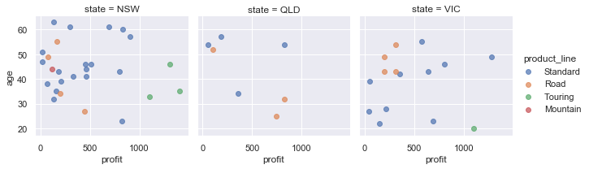

```python
import seaborn as sns
from matplotlib import pyplot as plt

#Provides a better looking layout for the plots
sns.set()

#the plots will be interactive(zoom, cursor)
%matplotlib inline

g = sns.FacetGrid(df_clean, col="state", hue="product_line")
g.map(plt.scatter, "profit", "age", alpha=.7)
g.add_legend();
```

```python
print('Correlation of profit with cars: {:.2f}'
     .format(df_clean['owns_car'].corr(df_clean['profit'])))
print('Correlation of profit with bike related purchases: {:.2f}'
     .format(df_clean['past_3_years_bike_related_purchases'].corr(df_clean['profit'])))
print('Correlation of profit with property valuation: {:.2f}'
     .format(df_clean['property_valuation'].corr(df_clean['profit'])))
```

```
Correlation of profit with cars: 0.14
Correlation of profit with bike related purchases: 0.20
Correlation of profit with property valuation: 0.17
```

```python
print(df_clean.groupby(["product_line","state"])['profit'].sum().sort_values(ascending=False))
```

```
product_line  state
Standard      NSW      7470.38
              VIC      4798.47
Touring       NSW      3817.59
Road          QLD      1680.42
Standard      QLD      1424.20
Touring       VIC      1103.43
Road          VIC      1016.06
              NSW       887.00
Mountain      NSW       114.93
Name: profit, dtype: float64
```

```python
df_clean.groupby('product_line').size()
```

```
product_line
Mountain     1
Road        11
Standard    33
Touring      4
dtype: int64
```

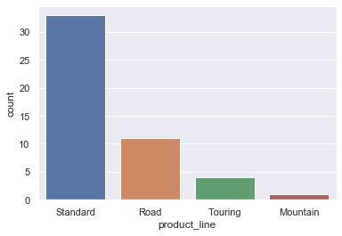

```python
sns.countplot(df_clean['product_line'],label="Count")
plt.show()
```

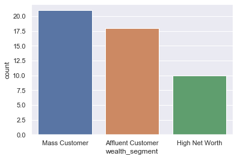

```python
sns.countplot(df_clean['wealth_segment'],label="Count")
plt.show()
```

```python
from sklearn.preprocessing import MinMaxScaler, LabelEncoder
from sklearn.model_selection import train_test_split

le=LabelEncoder()
scaler=MinMaxScaler()
df_clean['product_line']=le.fit_transform(df_clean['product_line'])
df_clean['state']=le.fit_transform(df_clean['state'])
features=['state','profit','product_line','owns_car','property_valuation']
X = df_clean[features]
y = df_clean['wealth_segment']
```

```python
X_train, X_test, y_train, y_test = train_test_split(X, y, random_state=1220)
X_train = scaler.fit_transform(X_train)
X_test = scaler.transform(X_test)
```

```python
from sklearn.tree import DecisionTreeClassifier
clf = DecisionTreeClassifier().fit(X_train, y_train)
print('Accuracy of Decision Tree classifier on training set: {:.2f}'
     .format(clf.score(X_train, y_train)))
print('Accuracy of Decision Tree classifier on test set: {:.2f}'
     .format(clf.score(X_test, y_test)))
```

```
Accuracy of Decision Tree classifier on training set: 1.00
Accuracy of Decision Tree classifier on test set: 0.62
```

```python
clf.predict(X_test)
```

```
array(['Mass Customer', 'Affluent Customer', 'Mass Customer',
       'Mass Customer', 'Affluent Customer', 'High Net Worth',
       'Mass Customer', 'Mass Customer', 'Mass Customer', 'Mass Customer',
       'Mass Customer', 'Mass Customer', 'Mass Customer'], dtype=object)
```